# wrangle_act_report

## Report: act_report

- Create a **250-word-minimum written report** called "act_report.pdf" or "act_report.html" that communicates the insights and displays the visualization(s) produced from your wrangled data. This is to be framed as an external document, like a blog post or magazine article, for example.

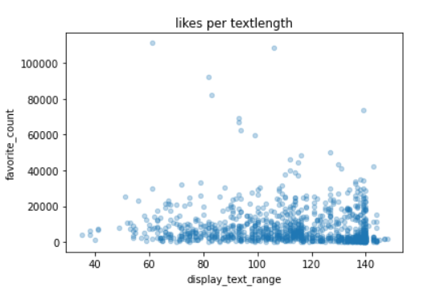

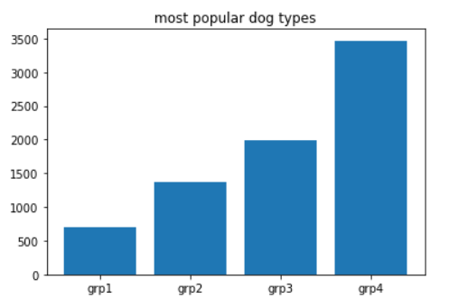

We have for groups , we can see that the group 4 is the most retweeted group , we can the types of group 4 dogs :

Afghan_hound , Australian_terrier , Bedlington_terrier , Border_terrier , Cardigan , Chesapeake_Bay_retriever , Chihuahua ,English_springer , French_bulldog , Gordon_setter , Great_Pyrenees , Irish_setter , Irish_water_spaniel, Leonberg,Norwegian_elkhound , Pembroke, Saluki, Samoyed, Walker_hound, basset , bloodhound , boxer , briard , cocker_spaniel , giant_schnauzer , golden_retriever, wire-haired_fox_terrier

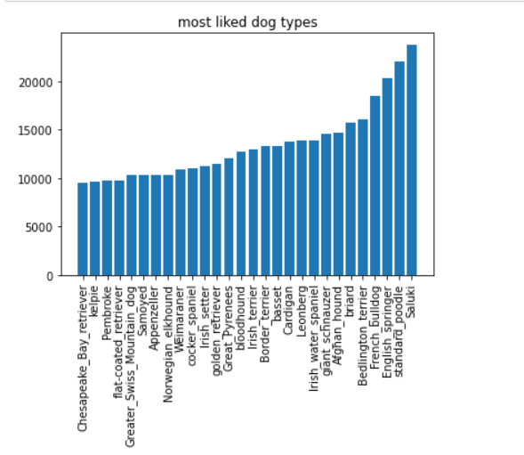

Those are the most loved dogs types , we can see the top three types :

#### -> Saluki | Standard Poodle | English Springer

#### are the most loved dogs categories